# IODS course project

Vitus Besel

# Introduction to Open Data Science - Course Project

# About the project

```r
# This is a so-called "R chunk" where you can write R code.

date()
```

```
## [1] "Mon Nov 23 13:43:38 2020"
```

# 2. Regression and model validation

### 1. Read in and describe the data

```r
learning2014 <- read.csv("data/learning2014.csv")
str(learning2014)
```

```
## 'data.frame':    166 obs. of  8 variables:
##  $ X       : int  1 2 3 4 5 6 7 8 9 10 ...
##  $ gender  : Factor w/ 2 levels "F","M": 1 2 1 2 2 1 2 1 2 1 ...
##  $ Age     : int  53 55 49 53 49 38 50 37 37 42 ...
##  $ Attitude: int  37 31 25 35 37 38 35 29 38 21 ...
##  $ deep    : num  3.58 2.92 3.5 3.5 3.67 ...
##  $ stra    : num  3.38 2.75 3.62 3.12 3.62 ...
##  $ surf    : num  2.58 3.17 2.25 2.25 2.83 ...
##  $ Points  : int  25 12 24 10 22 21 21 31 24 26 ...
```

```r
dim(learning2014)
```

```
## [1] 166   8
```

The data consists of 166 observations for 7 variables (the 8th variable is merely an index here). The data has been collected over the course *Introduction to Social Statistics* in 2014. Non-selfexplanatory columns are:

- “deep”: Deep learning evaluation
- “stra”: Strategic learning evaluation
- “surf”; Surface learning evaluation

More details available at http://www.helsinki.fi/~kvehkala/JYTmooc/JYTOPKYS3-meta.txt

### 2. Graphical overview of the data

```r
library(GGally)
```

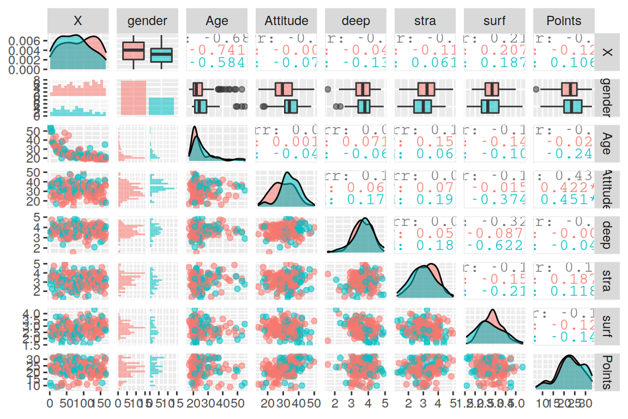

```r
library(ggplot2)
# create a more advanced plot matrix with ggpairs()
p <- ggpairs(learning2014, mapping = aes(col = gender, alpha = 0.3), lower = list(combo = wrap("facethist", bins = 20)))
# draw the plot
p
```

```r
summary(learning2014)
```

```
##        X          gender       Age           Attitude          deep
##  Min.   :  1.00   F:110   Min.   :17.00   Min.   :14.00   Min.   :1.583
##  1st Qu.: 42.25   M: 56   1st Qu.:21.00   1st Qu.:26.00   1st Qu.:3.333
##  Median : 83.50           Median :22.00   Median :32.00   Median :3.667
##  Mean   : 83.50           Mean   :25.51   Mean   :31.43   Mean   :3.680
##  3rd Qu.:124.75           3rd Qu.:27.00   3rd Qu.:37.00   3rd Qu.:4.083
##  Max.   :166.00           Max.   :55.00   Max.   :50.00   Max.   :4.917
##       stra            surf           Points
##  Min.   :1.250   Min.   :1.583   Min.   : 7.00
##  1st Qu.:2.625   1st Qu.:2.417   1st Qu.:19.00
##  Median :3.188   Median :2.833   Median :23.00
##  Mean   :3.121   Mean   :2.787   Mean   :22.72
##  3rd Qu.:3.625   3rd Qu.:3.167   3rd Qu.:27.75
##  Max.   :5.000   Max.   :4.333   Max.   :33.00
```

Blue represents data where gender is “male”, red where gender is “female”. The table overview shows that the data consists to only one third of data with gender being “male”, The graphical overview shows that higher points correlate with a better attitude. Otherwise barely any correlation can be stated visually.

### 3. Regression model

```r
my_model2 <- lm(Points ~ Attitude + stra + Age , data = learning2014)
summary(my_model2)
```

```
##
## Call:
## lm(formula = Points ~ Attitude + stra + Age, data = learning2014)
##
## Residuals:
##      Min       1Q   Median       3Q      Max
## -18.1149  -3.2003   0.3303   3.4129  10.7599
##
## Coefficients:
##             Estimate Std. Error t value Pr(>|t|)
## (Intercept) 10.89543    2.64834   4.114 6.17e-05 ***
## Attitude     0.34808    0.05622   6.191 4.72e-09 ***
## stra         1.00371    0.53434   1.878   0.0621 .
## Age         -0.08822    0.05302  -1.664   0.0981 .
## ---
## Signif. codes:  0 '***' 0.001 '**' 0.01 '*' 0.05 '.' 0.1 ' ' 1
##
## Residual standard error: 5.26 on 162 degrees of freedom
## Multiple R-squared:  0.2182, Adjusted R-squared:  0.2037
## F-statistic: 15.07 on 3 and 162 DF,  p-value: 1.07e-08
```

```r
my_model2 <- lm(Points ~ Attitude, data = learning2014)
summary(my_model2)
```

```
##
## Call:
## lm(formula = Points ~ Attitude, data = learning2014)
##
## Residuals:
##      Min       1Q   Median       3Q      Max
## -16.9763  -3.2119   0.4339   4.1534  10.6645
##
## Coefficients:
##             Estimate Std. Error t value Pr(>|t|)
## (Intercept) 11.63715    1.83035   6.358 1.95e-09 ***
## Attitude     0.35255    0.05674   6.214 4.12e-09 ***
## ---
## Signif. codes:  0 '***' 0.001 '**' 0.01 '*' 0.05 '.' 0.1 ' ' 1
##
## Residual standard error: 5.32 on 164 degrees of freedom
## Multiple R-squared:  0.1906, Adjusted R-squared:  0.1856
## F-statistic: 38.61 on 1 and 164 DF,  p-value: 4.119e-09
```

Now our model is statistically significant.

### 4. Interpretation of the model

The intercept tells us that someone with 0 attitude will have 11.6 points. From there for each “Attitude” increment the “Points” will rise by 0.35. Someone with the maximum of 50 in attitude will have a predicted point score of 17 + 11 = 28. We have a linear relationship here. The multiple r-squared is always between 0 and 1 and the higher the more variation in the response variable is explained by the model. The same is true for the adjusted r-squared just that it takes into account the number of independent variables. Our model is therefore not well suited to explain this variation as the value is only 0.19.

### 5. Plot Residuals

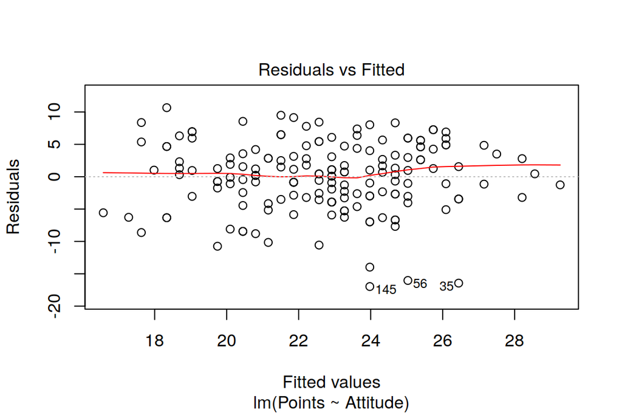

```r
plot(my_model2, which = 1)
```

Ideally the residual would be as close to 0 as possible. We have a quite big spreading, which is also reflected by our poor r-squared.

The normal Q-Q plot plots the quantiles of two different probability distributions against each other. Ideally all the values are on the diagonal:

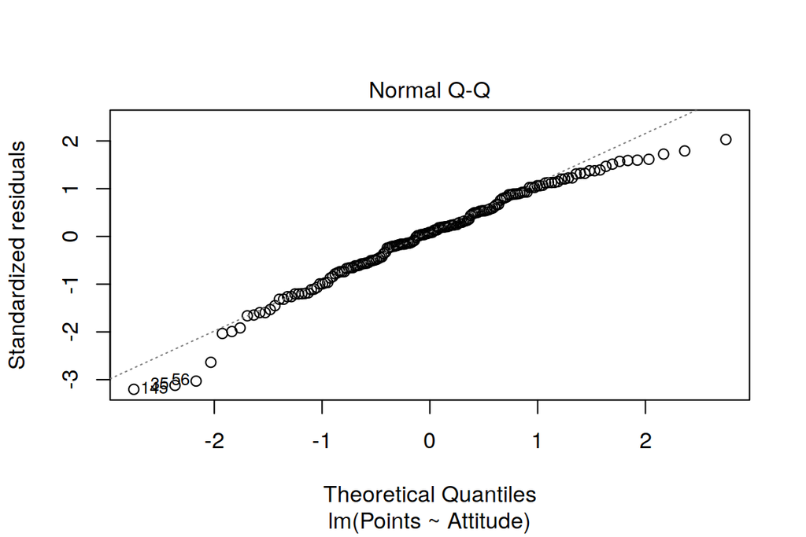

```r
plot(my_model2, which = 2)
```

We can see that for the outer quantiles the values diverge from the quantiles.

*Leverage* describes how far a covariate is from other covariates, respectively for the present assumed linear regression it measures how sensitive a predicted value is to a change of the corresponding true value:

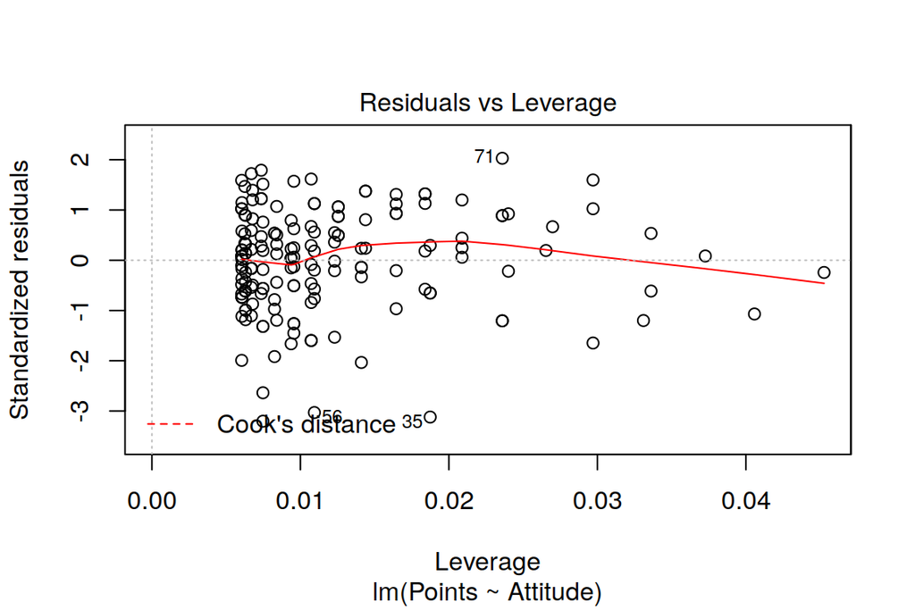

```r
plot(my_model2, which = 5)
```

The points are more or less evenly spread.

# 3. Logistic Regression

### 2. Read in and describe the data

```r
alc <- read.csv("data/alc.csv")
colnames(alc)
```

```
##  [1] "X"          "school"     "sex"        "age"        "address"
##  [6] "famsize"    "Pstatus"    "Medu"       "Fedu"       "Mjob"
## [11] "Fjob"       "reason"     "nursery"    "internet"   "guardian"
## [16] "traveltime" "studytime"  "failures"   "schoolsup"  "famsup"
## [21] "paid"       "activities" "higher"     "romantic"   "famrel"
## [26] "freetime"   "goout"      "Dalc"       "Walc"       "health"
## [31] "absences"   "G1"         "G2"         "G3"         "alc_use"
## [36] "high_use"
```

The data contains information about student achievements in secondary eduction of two Portugese schools. It includes students grades, demographic, social and school related features, which were collected via questionnaries. More information at: https://archive.ics.uci.edu/ml/datasets/Student+Performance

### 3. Hypotheses for relationships of alcohol consumption to chosen variables

Personally I would except students with high alcohol consumption (**high_use**) to have worse grades (**G3**), more absences (**absences**), worse health (**health**) and more class failures (**failures**).

### 4. Explore Hypotheses

Let’s explore these hypotheses, first numerically:

```r
table(high_use = alc$high_use, grade = alc$G3)
```

```
##         grade
## high_use  0  2  3  4  5  6  7  8  9 10 11 12 13 14 15 16 17 18
##    FALSE  1  0  1  6  4 15  4 19  3 38 16 54 19 31 15 30  5  7
##    TRUE   1  1  0  1  2  7  2  8  4 26 10 27  7  7  1  8  2  0
```

```r
table(high_use = alc$high_use, absences = alc$absences)
```

```
##         absences
## high_use  0  1  2  3  4  5  6  7  8  9 10 11 12 13 14 16 17 18 19 20 21 26 27
##    FALSE 52 38 42 33 24 16 16  9 14  6  5  2  4  1  1  0  0  1  0  2  1  0  0
##    TRUE  13 13 16  8 12  6  5  3  6  6  2  4  4  1  6  1  1  1  1  0  1  1  1
##         absences
## high_use 29 44 45
##    FALSE  0  0  1
##    TRUE   1  1  0
```

```r
table(high_use = alc$high_use, health = alc$health)
```

```
##         health
## high_use  1  2  3  4  5
##    FALSE 35 28 62 49 94
##    TRUE  11 16 19 18 50
```

```r
table(high_use = alc$high_use, failures = alc$failures)
```

```
##         failures
## high_use   0   1   2   3
##    FALSE 244  12  10   2
##    TRUE   90  12   9   3
```

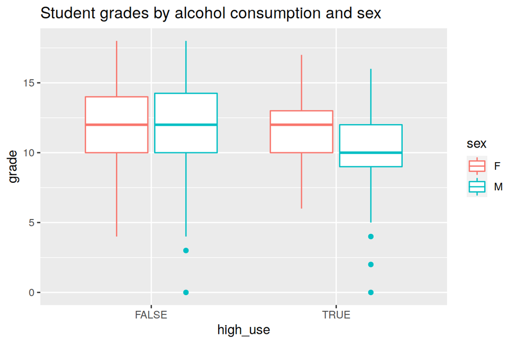

```r
library(ggplot2)
g1 <- ggplot(alc, aes(x = high_use, y = G3, col = sex))
g1 + geom_boxplot() + ylab("grade")   + ggtitle("Student grades by alcohol consumption and sex")
```

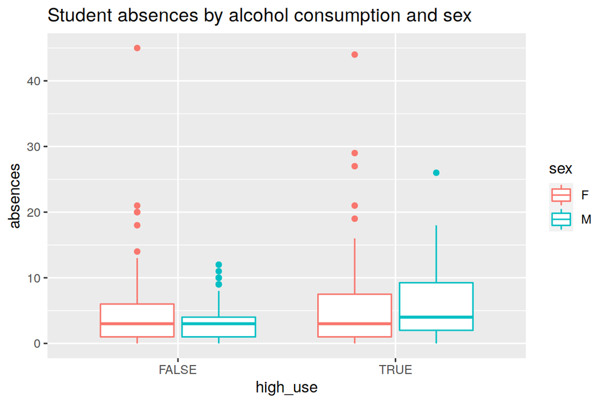

```r
g2 <- ggplot(alc, aes(x = high_use, y = absences, col = sex))
g2 + geom_boxplot() + ylab("absences")   + ggtitle("Student absences by alcohol consumption and sex")
```

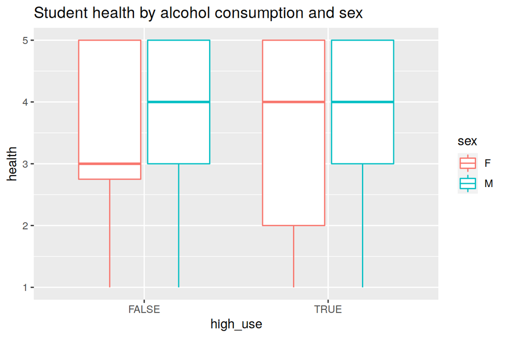

```r
g3 <- ggplot(alc, aes(x = high_use, y = health, col = sex))
g3 + geom_boxplot() + ylab("health")   + ggtitle("Student health by alcohol consumption and sex")
```

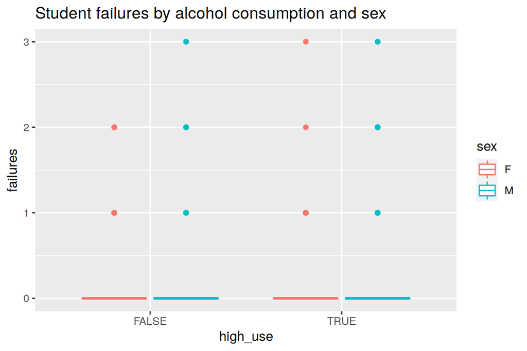

```r
g4 <- ggplot(alc, aes(x = high_use, y = failures, col = sex))
g4 + geom_boxplot() + ylab("failures")   + ggtitle("Student failures by alcohol consumption and sex")
```

### 5. Logistic Regression

```r
m <- glm(high_use ~ G3 + absences + health + failures, data = alc, family = "binomial")
summary(m)
```

```
##
## Call:
## glm(formula = high_use ~ G3 + absences + health + failures, family = "binomial",
##     data = alc)
##
## Deviance Residuals:
##     Min       1Q   Median       3Q      Max
## -2.3178  -0.7943  -0.7015   1.1814   1.9006
##
## Coefficients:
##             Estimate Std. Error z value Pr(>|z|)
## (Intercept) -1.13164    0.58665  -1.929 0.053731 .
## G3          -0.04286    0.03791  -1.131 0.258225
## absences     0.08458    0.02283   3.705 0.000212 ***
## health       0.07387    0.08602   0.859 0.390474
## failures     0.39341    0.19912   1.976 0.048184 *
## ---
## Signif. codes:  0 '***' 0.001 '**' 0.01 '*' 0.05 '.' 0.1 ' ' 1
##
## (Dispersion parameter for binomial family taken to be 1)
##
##     Null deviance: 465.68  on 381  degrees of freedom
## Residual deviance: 437.96  on 377  degrees of freedom
## AIC: 447.96
##
## Number of Fisher Scoring iterations: 4
```

The logistic regression model contradicts my earlier conclusions and shows that **health** and **grades** are not statistically significant while **failures** is. Consequently I drop **health** and **grades** from the model.

```r
m <- glm(high_use ~ failures + absences, data = alc, family = "binomial")
summary(m)
```

```
##
## Call:
## glm(formula = high_use ~ failures + absences, family = "binomial",
##     data = alc)
##
## Deviance Residuals:
##     Min       1Q   Median       3Q      Max
## -2.2680  -0.8019  -0.6967   1.2522   1.7906
##
## Coefficients:
##             Estimate Std. Error z value Pr(>|z|)
## (Intercept) -1.37829    0.16479  -8.364  < 2e-16 ***
## failures     0.49972    0.18456   2.708 0.006776 **
## absences     0.08602    0.02287   3.762 0.000169 ***
## ---
## Signif. codes:  0 '***' 0.001 '**' 0.01 '*' 0.05 '.' 0.1 ' ' 1
##
## (Dispersion parameter for binomial family taken to be 1)
##
##     Null deviance: 465.68  on 381  degrees of freedom
## Residual deviance: 440.14  on 379  degrees of freedom
## AIC: 446.14
##
## Number of Fisher Scoring iterations: 4
```

```r
coef(m)
```

```
## (Intercept)    failures    absences
## -1.37828639  0.49971697  0.08601774
```

Let’s turn the coefficients into odds ratios with confidence intervals:

[output not shown]

### 6. Predictive Power

Let’s make predictions with our two variables:

```r
library(dplyr)
# predict() the probability of high_use
probabilities <- predict(m, type = "response")

# add the predicted probabilities to 'alc'
alc <- mutate(alc, probability = probabilities)

# use the probabilities to make a prediction of high_use
alc <- mutate(alc, prediction = probability > 0.5)

# tabulate the target variable versus the predictions
table(high_use = alc$high_use, prediction = alc$prediction)
```

```
##         prediction
## high_use FALSE TRUE
##    FALSE   258   10
##    TRUE     99   15
```

### 7. Cross-validation

For crossvalidation we need to define a const function:

```r
loss_func <- function(class, prob) {
  n_wrong <- abs(class - prob) > 0.5
  mean(n_wrong)
}
```

next we perform 10 fold crossvalidation:

```r
library(boot)
cv <- cv.glm(data = alc, cost = loss_func, glmfit = m, K = 10)
cv$delta[1]
```

```
## [1] 0.2905759
```

Crossvalidation seems to make the prediction worse in the present case.

# 4. Clustering and Classification

### 2. Load and describe the data

```r
library(MASS)
data("Boston")
str(Boston)
```

```
## 'data.frame':    506 obs. of  14 variables:
##  $ crim   : num  0.00632 0.02731 0.02729 0.03237 0.06905 ...
##  $ zn     : num  18 0 0 0 0 0 12.5 12.5 12.5 12.5 ...
##  $ indus  : num  2.31 7.07 7.07 2.18 2.18 2.18 7.87 7.87 7.87 7.87 ...
##  $ chas   : int  0 0 0 0 0 0 0 0 0 0 ...
##  $ nox    : num  0.538 0.469 0.469 0.458 0.458 0.458 0.524 0.524 0.524 0.524 ...
##  $ rm     : num  6.58 6.42 7.18 7 7.15 ...
##  $ age    : num  65.2 78.9 61.1 45.8 54.2 58.7 66.6 96.1 100 85.9 ...
##  $ dis    : num  4.09 4.97 4.97 6.06 6.06 ...
##  $ rad    : int  1 2 2 3 3 3 5 5 5 5 ...
##  $ tax    : num  296 242 242 222 222 222 311 311 311 311 ...
##  $ ptratio: num  15.3 17.8 17.8 18.7 18.7 18.7 15.2 15.2 15.2 15.2 ...
##  $ black  : num  397 397 393 395 397 ...
##  $ lstat  : num  4.98 9.14 4.03 2.94 5.33 ...
##  $ medv   : num  24 21.6 34.7 33.4 36.2 28.7 22.9 27.1 16.5 18.9 ...
```

The data contains information about housing values in suburbs of Boston. It contains information regarding crime rates, proportions of residental land/non-retail and various other variables influencing housing values, detailed information here: https://stat.ethz.ch/R-manual/R-devel/library/MASS/html/Boston.html There are **506** observables of **14** variables.

### 3. Graphical overview

For obtaining an graphical overview of the data it is here useful to plot a **Correlation matrix** additional to the summary.

```r
library(dplyr)
library(tidyverse)
```

```r
library(corrplot)
summary(Boston)
```

```
##       crim                zn             indus            chas
##  Min.   : 0.00632   Min.   :  0.00   Min.   : 0.46   Min.   :0.00000
##  1st Qu.: 0.08204   1st Qu.:  0.00   1st Qu.: 5.19   1st Qu.:0.00000
##  Median : 0.25651   Median :  0.00   Median : 9.69   Median :0.00000
##  Mean   : 3.61352   Mean   : 11.36   Mean   :11.14   Mean   :0.06917
##  3rd Qu.: 3.67708   3rd Qu.: 12.50   3rd Qu.:18.10   3rd Qu.:0.00000
##  Max.   :88.97620   Max.   :100.00   Max.   :27.74   Max.   :1.00000
##       nox               rm             age              dis
##  Min.   :0.3850   Min.   :3.561   Min.   :  2.90   Min.   : 1.130
##  1st Qu.:0.4490   1st Qu.:5.886   1st Qu.: 45.02   1st Qu.: 2.100
##  Median :0.5380   Median :6.208   Median : 77.50   Median : 3.207
##  Mean   :0.5547   Mean   :6.285   Mean   : 68.57   Mean   : 3.795
##  3rd Qu.:0.6240   3rd Qu.:6.623   3rd Qu.: 94.08   3rd Qu.: 5.188
##  Max.   :0.8710   Max.   :8.780   Max.   :100.00   Max.   :12.127
##       rad              tax           ptratio          black
##  Min.   : 1.000   Min.   :187.0   Min.   :12.60   Min.   :  0.32
##  1st Qu.: 4.000   1st Qu.:279.0   1st Qu.:17.40   1st Qu.:375.38
##  Median : 5.000   Median :330.0   Median :19.05   Median :391.44
##  Mean   : 9.549   Mean   :408.2   Mean   :18.46   Mean   :356.67
##  3rd Qu.:24.000   3rd Qu.:666.0   3rd Qu.:20.20   3rd Qu.:396.23
##  Max.   :24.000   Max.   :711.0   Max.   :22.00   Max.   :396.90
##      lstat            medv
##  Min.   : 1.73   Min.   : 5.00
##  1st Qu.: 6.95   1st Qu.:17.02
##  Median :11.36   Median :21.20
##  Mean   :12.65   Mean   :22.53
##  3rd Qu.:16.95   3rd Qu.:25.00
##  Max.   :37.97   Max.   :50.00
```

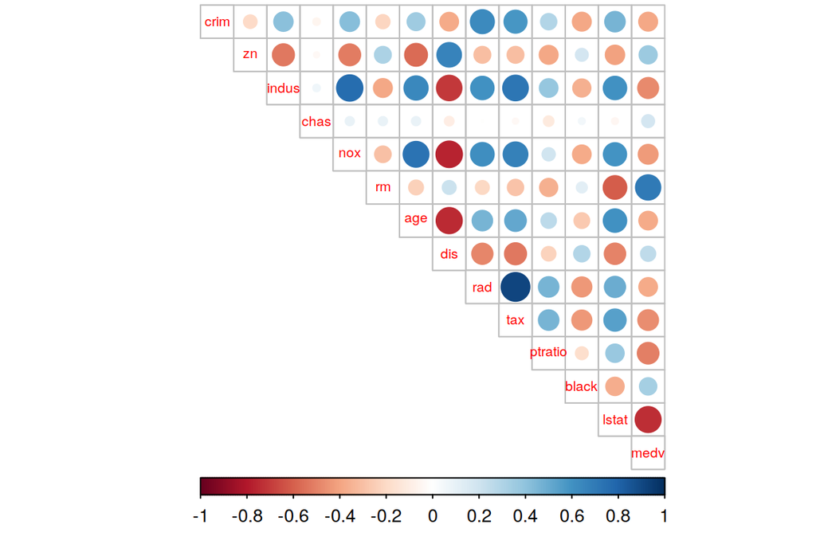

```r
# calculate the correlation matrix and round it
cor_matrix<-cor(Boston) %>% round(digits = 2)

# visualize the correlation matrix
corrplot(cor_matrix, method="circle", type="upper", cl.pos = "b", tl.pos = "d", tl.cex = 0.6)
```

*crim*, that is crime rates, is the only variable the spans over several order of magnitudes. Otherwise most of the data is in a range of tens and hundreds. There is lots of correlation within the data. Only exception is *chas*, (Charles River dummy variable (= 1 if tract bounds river; 0 otherwise)). Also *black* (measure for the proprtion of black population) shows rather small correlationss. We have various clear correlations that feel intuitively right, such as *indus* (industry proportion) with *nox* (nitrogen oxide concentration) or a negative correlation of *lstat* (lower status of populatrion in %) to *medv* (median value of homes).

### 4. Standardize Data

We will standardize the data:

```r
# center and standardize variables
boston_scaled <- scale(Boston)

# summaries of the scaled variables
summary(boston_scaled)
```

```
##       crim                 zn               indus              chas
##  Min.   :-0.419367   Min.   :-0.48724   Min.   :-1.5563   Min.   :-0.2723
##  1st Qu.:-0.410563   1st Qu.:-0.48724   1st Qu.:-0.8668   1st Qu.:-0.2723
##  Median :-0.390280   Median :-0.48724   Median :-0.2109   Median :-0.2723
##  Mean   : 0.000000   Mean   : 0.00000   Mean   : 0.0000   Mean   : 0.0000
##  3rd Qu.: 0.007389   3rd Qu.: 0.04872   3rd Qu.: 1.0150   3rd Qu.:-0.2723
##  Max.   : 9.924110   Max.   : 3.80047   Max.   : 2.4202   Max.   : 3.6648
##       nox                rm               age               dis
##  Min.   :-1.4644   Min.   :-3.8764   Min.   :-2.3331   Min.   :-1.2658
##  1st Qu.:-0.9121   1st Qu.:-0.5681   1st Qu.:-0.8366   1st Qu.:-0.8049
##  Median :-0.1441   Median :-0.1084   Median : 0.3171   Median :-0.2790
##  Mean   : 0.0000   Mean   : 0.0000   Mean   : 0.0000   Mean   : 0.0000
##  3rd Qu.: 0.5981   3rd Qu.: 0.4823   3rd Qu.: 0.9059   3rd Qu.: 0.6617
##  Max.   : 2.7296   Max.   : 3.5515   Max.   : 1.1164   Max.   : 3.9566
##       rad               tax             ptratio            black
##  Min.   :-0.9819   Min.   :-1.3127   Min.   :-2.7047   Min.   :-3.9033
##  1st Qu.:-0.6373   1st Qu.:-0.7668   1st Qu.:-0.4876   1st Qu.: 0.2049
##  Median :-0.5225   Median :-0.4642   Median : 0.2746   Median : 0.3808
##  Mean   : 0.0000   Mean   : 0.0000   Mean   : 0.0000   Mean   : 0.0000
##  3rd Qu.: 1.6596   3rd Qu.: 1.5294   3rd Qu.: 0.8058   3rd Qu.: 0.4332
##  Max.   : 1.6596   Max.   : 1.7964   Max.   : 1.6372   Max.   : 0.4406
##      lstat              medv
##  Min.   :-1.5296   Min.   :-1.9063
##  1st Qu.:-0.7986   1st Qu.:-0.5989
##  Median :-0.1811   Median :-0.1449
##  Mean   : 0.0000   Mean   : 0.0000
##  3rd Qu.: 0.6024   3rd Qu.: 0.2683
##  Max.   : 3.5453   Max.   : 2.9865
```

```r
# change the object to data frame
boston_scaled <- as.data.frame(boston_scaled)
```

Standardizing set all data means to zero. Now we turn *crim* into a categorical variable, based on its quantiles. Finally we will put 80% of the data into a train set and the rest to a testset.

```r
# create a quantile vector of crim and print it
bins <- quantile(boston_scaled$crim)

# create a categorical variable 'crime'
crime <- cut(boston_scaled$crim, breaks = bins, include.lowest = TRUE, label = c("low","med_low","med_high","high"))

# remove original crim from the dataset
boston_scaled <- dplyr::select(boston_scaled, -crim)

# add the new categorical value to scaled data
boston_scaled <- data.frame(boston_scaled, crime)

# number of rows in the Boston dataset
n <- nrow(Boston)

# choose randomly 80% of the rows
ind <- sample(n,  size = n * 0.8)

# create train set
train <- boston_scaled[ind,]

# create test set
test <- boston_scaled[-ind,]
```

The categorical *crime* data is split into four categories of low, medium low, medium high and high crime rates.

### 5. Linear Discriminant Analysis

Let*s fit a Linear Discriminant Analysis model on the data:

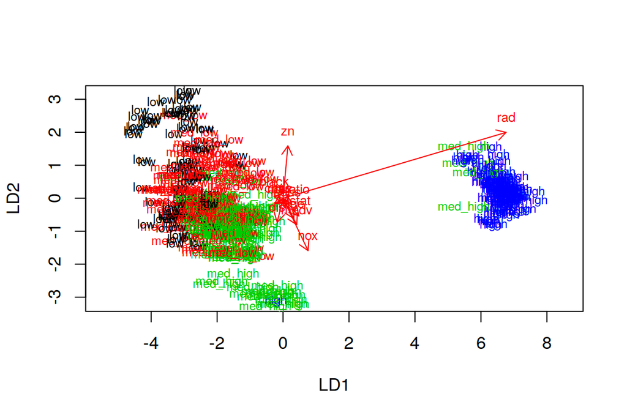

```r
# linear discriminant analysis
lda.fit <- lda(crime ~ ., data = train)

# the function for lda biplot arrows
lda.arrows <- function(x, myscale = 1, arrow_heads = 0.1, color = "red", tex = 0.75, choices = c(1,2)){
  heads <- coef(x)
  arrows(x0 = 0, y0 = 0,
         x1 = myscale * heads[,choices[1]],
         y1 = myscale * heads[,choices[2]], col=color, length = arrow_heads)
  text(myscale * heads[,choices], labels = row.names(heads),
       cex = tex, col=color, pos=3)
}

# target classes as numeric
classes <- as.numeric(train$crime)

# plot the lda results
plot(lda.fit, dimen = 2, col = classes, pch = classes)
lda.arrows(lda.fit, myscale = 2)
```

### 6. Predictions onto the testset

Let*s fit a Linear Discriminant Analysis model on the data:

```r
# save the correct classes from test data
correct_classes <- test$crime

# remove the crime variable from test data
test <- dplyr::select(test, -crime)

# predict classes with test data
lda.pred <- predict(lda.fit, newdata = test)

# cross tabulate the results
table(correct = correct_classes, predicted = lda.pred$class)
```

```
##           predicted
## correct    low med_low med_high high
##   low       13      12        1    0
##   med_low    4      15        4    0
##   med_high   0       4       21    2
##   high       0       0        0   26
```

### 7. Data Distances

Let’s reload the dataset and calculate distances between the variables and then run the k-means algorithm

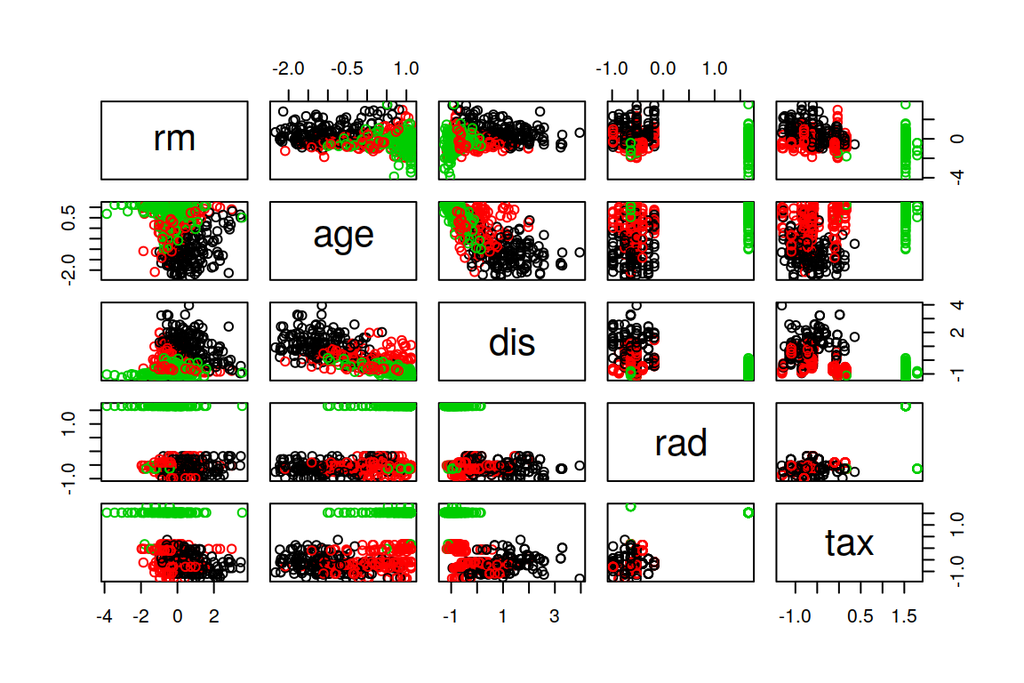

```r
# load MASS and Boston
library(MASS)
data('Boston')

boston_scaled <- scale(Boston)
boston_scaled <- as.data.frame(boston_scaled)
# euclidean distance matrix
dist_eu <- dist(boston_scaled)

# k-means clustering
km <-kmeans(boston_scaled, centers = 3)

# plot the Boston dataset with clusters
pairs(boston_scaled[6:10], col = km$cluster)
```

With 3 clusters we get some distinction of the datapoints, however, the graph makes clear that it could be separated more and better. Therefore, we observe the total of within cluster sum of squares (WCSS). When this measure is lowest we fidn the optimal number of clusters.

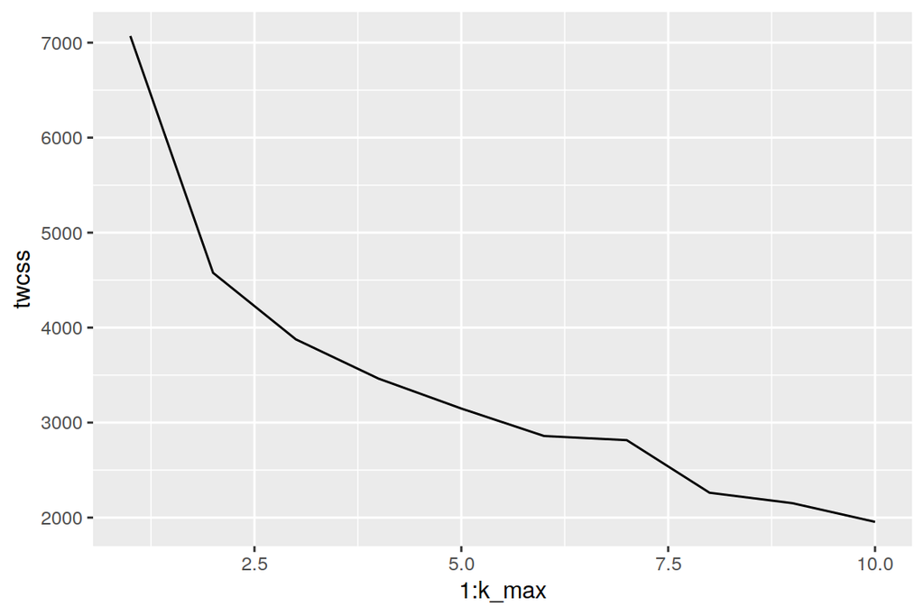

```r
set.seed(123)

# determine the number of clusters
k_max <- 10

# calculate the total within sum of squares
twcss <- sapply(1:k_max, function(k){kmeans(boston_scaled, k)$tot.withinss})

# visualize the results
qplot(x = 1:k_max, y = twcss, geom = 'line')
```

The graph suggests that we may find a better results with 10 clusters. However, that may be a overfit, so we take 8 instead as there is a rapid decline in the curve right before 8 clusters.

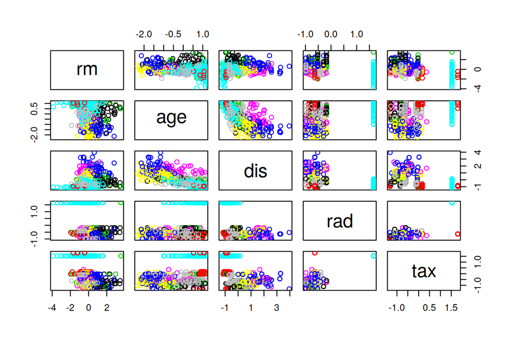

```r
# k-means clustering
km <-kmeans(boston_scaled, centers = 8)

# plot the Boston dataset with clusters
pairs(boston_scaled[6:10], col = km$cluster)
```

Visually the result got worse, because it is way more difficult to achieve any interpretation of the result. With 8 clusters therer is already some overfit. Nevertheless, the brightblue cluster seems to be well described.

# 5. Principal Component Analysis

### 1. Graphical overviews and summaries

```r
library(GGally)
humans <- read.csv("https://s3.amazonaws.com/assets.datacamp.com/production/course_2218/datasets/human2.txt", row.names = 1, header= TRUE)
summary(humans)
```

```
##     Edu2.FM          Labo.FM          Edu.Exp         Life.Exp
##  Min.   :0.1717   Min.   :0.1857   Min.   : 5.40   Min.   :49.00
##  1st Qu.:0.7264   1st Qu.:0.5984   1st Qu.:11.25   1st Qu.:66.30
##  Median :0.9375   Median :0.7535   Median :13.50   Median :74.20
##  Mean   :0.8529   Mean   :0.7074   Mean   :13.18   Mean   :71.65
##  3rd Qu.:0.9968   3rd Qu.:0.8535   3rd Qu.:15.20   3rd Qu.:77.25
##  Max.   :1.4967   Max.   :1.0380   Max.   :20.20   Max.   :83.50
##       GNI            Mat.Mor         Ado.Birth         Parli.F
##  Min.   :   581   Min.   :   1.0   Min.   :  0.60   Min.   : 0.00
##  1st Qu.:  4198   1st Qu.:  11.5   1st Qu.: 12.65   1st Qu.:12.40
##  Median : 12040   Median :  49.0   Median : 33.60   Median :19.30
##  Mean   : 17628   Mean   : 149.1   Mean   : 47.16   Mean   :20.91
##  3rd Qu.: 24512   3rd Qu.: 190.0   3rd Qu.: 71.95   3rd Qu.:27.95
##  Max.   :123124   Max.   :1100.0   Max.   :204.80   Max.   :57.50
```

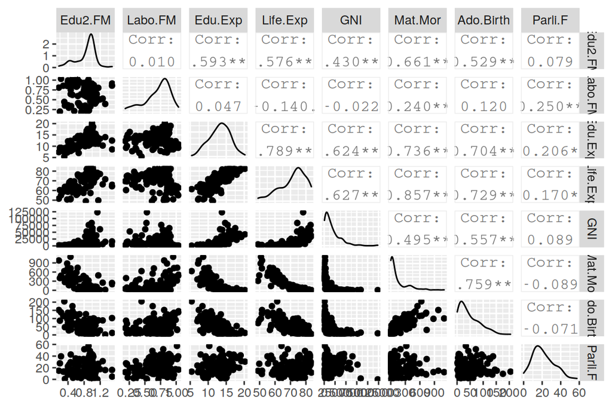

```r
ggpairs(humans)
```

The summary shows us that we have a variety of ranges for our data. GNI and Mat.Mor are widely spread ranging over three orders of magnitude. The other variables are more compact. The plot shows us that we have fairly strong correlations across the board. So does Ado.Birth correlate strongly with maternal mortality, life expectancy as well as education. However, e.g. female labour shows weak to none correlation.

### 2. PCA on **NON** standardized data

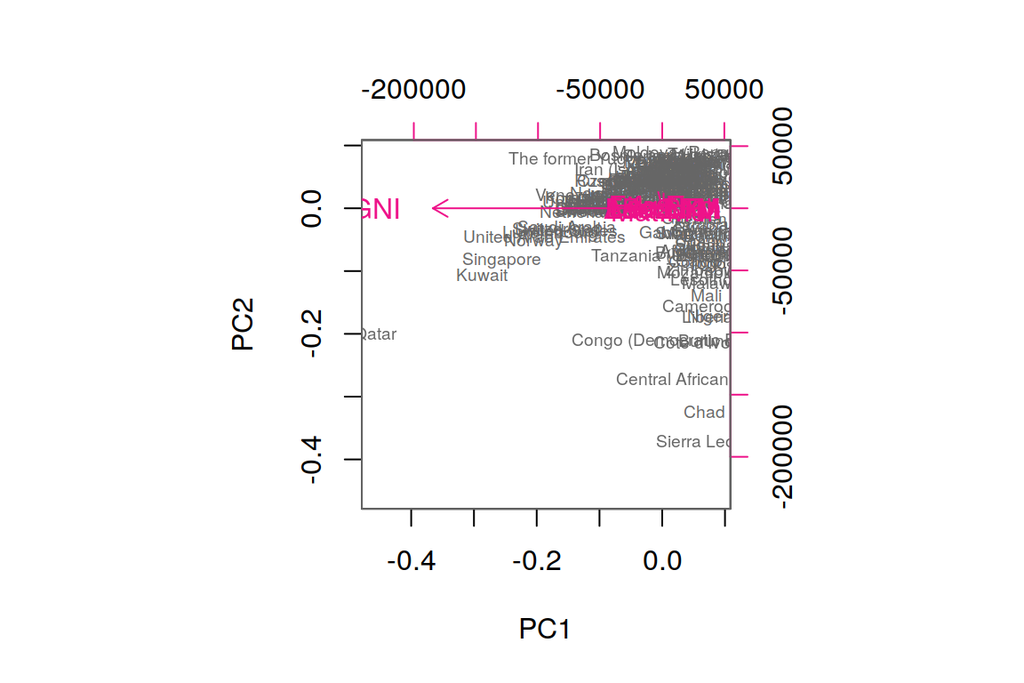

```r
# perform principal component analysis (with the SVD method)
pca_human <- prcomp(humans)

# draw a biplot of the principal component representation and the original variables
biplot(pca_human, choices = 1:2, cex = c(0.6, 1), col = c("grey40", "deeppink2"))
```